# hw2

SeungMin

2019년 3월 14일

```r
setwd("C:/Users/wjssm/Desktop/0.graduate/3rd/Statistical_Graphics/hw/hw2")
library(tidyverse)
library(gridExtra)
diamonds
```

```
## # A tibble: 53,940 x 10
##    carat cut       color clarity depth table price     x     y     z
##    <dbl> <ord>     <ord> <ord>   <dbl> <dbl> <int> <dbl> <dbl> <dbl>
##  1 0.23  Ideal     E     SI2      61.5    55   326  3.95  3.98  2.43
##  2 0.21  Premium   E     SI1      59.8    61   326  3.89  3.84  2.31
##  3 0.23  Good      E     VS1      56.9    65   327  4.05  4.07  2.31
##  4 0.290 Premium   I     VS2      62.4    58   334  4.2   4.23  2.63
##  5 0.31  Good      J     SI2      63.3    58   335  4.34  4.35  2.75
##  6 0.24  Very Good J     VVS2     62.8    57   336  3.94  3.96  2.48
##  7 0.24  Very Good I     VVS1     62.3    57   336  3.95  3.98  2.47
##  8 0.26  Very Good H     SI1      61.9    55   337  4.07  4.11  2.53
##  9 0.22  Fair      E     VS2      65.1    61   337  3.87  3.78  2.49
## 10 0.23  Very Good H     VS1      59.4    61   338  4     4.05  2.39
## # ... with 53,930 more rows
```

# 1

```r
summary(diamonds %>% select(8:10))
```

```
##        x                y                z
##  Min.   : 0.000   Min.   : 0.000   Min.   : 0.000
##  1st Qu.: 4.710   1st Qu.: 4.720   1st Qu.: 2.910
##  Median : 5.700   Median : 5.710   Median : 3.530
##  Mean   : 5.731   Mean   : 5.735   Mean   : 3.539
##  3rd Qu.: 6.540   3rd Qu.: 6.540   3rd Qu.: 4.040
##  Max.   :10.740   Max.   :58.900   Max.   :31.800
```

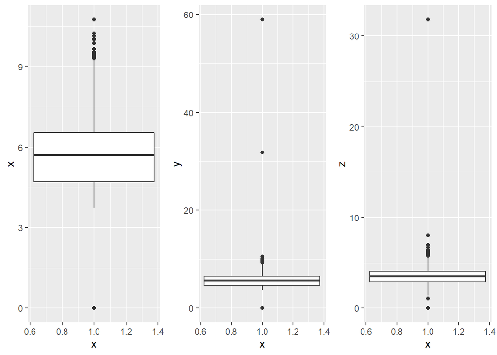

```r
#boxplot
p_x <-ggplot(diamonds)+geom_boxplot(aes(1,x))
p_y <-ggplot(diamonds)+geom_boxplot(aes(1,y))
p_z <-ggplot(diamonds)+geom_boxplot(aes(1,z))

grid.arrange(p_x, p_y, p_z, nrow =1)
```

x 는 0~10.74에 분포 / y는 0~58.900에 분포 / z 는 0~31.800 x,y,z모두 outlier가 존재한다.

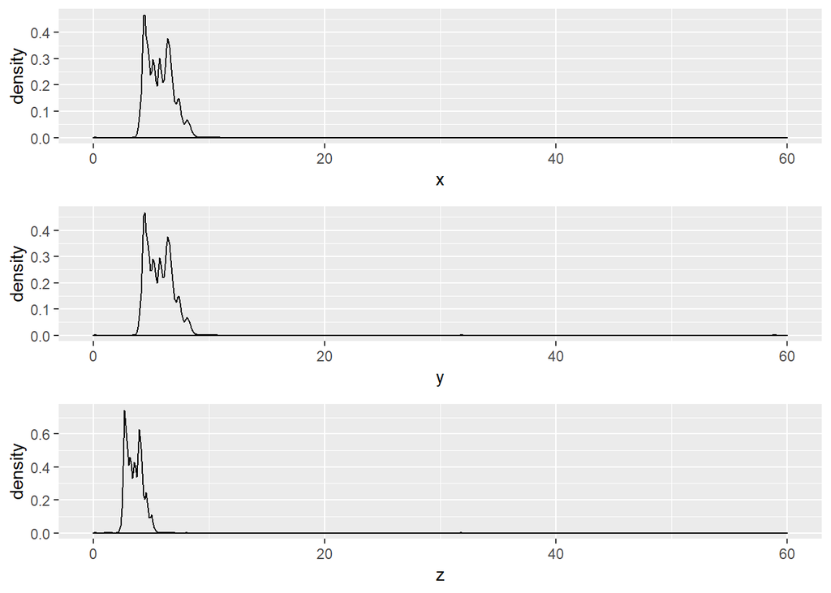

```r
p_x <-ggplot(diamonds)+geom_density(aes(x))+xlim(c(0,60))
p_y <-ggplot(diamonds)+geom_density(aes(y))+xlim(c(0,60))
p_z <-ggplot(diamonds)+geom_density(aes(z))+xlim(c(0,60))

grid.arrange(p_x, p_y, p_z, ncol =1)
```

- 세 변수 모두 skewed to right.
- 대부분의 다이아몬드가 작은 값에 모여있다.
- x,y,z 의 분포 모양이 비슷하다.
- range가 가장 넓은 y : width / z : depth / x : length

# 2.

```r
summary(diamonds$price)
```

```
##    Min. 1st Qu.  Median    Mean 3rd Qu.    Max.
##     326     950    2401    3933    5324   18823
```

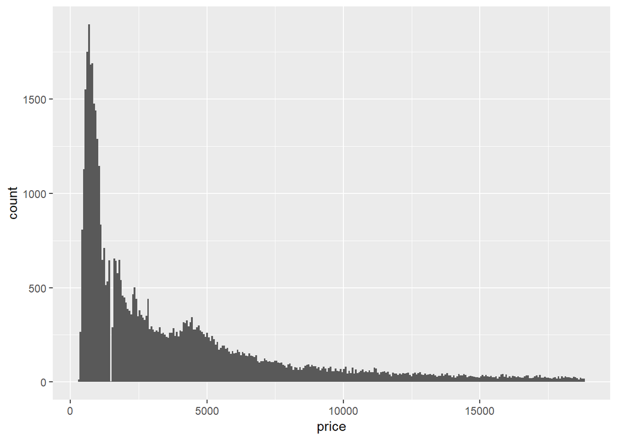

```r
ggplot(diamonds) + geom_histogram(aes(x = price),bins = 300)
```

히스토그램의 구간을 촘촘히 해보니까, 중간에 값이 비어있는 구간이 보인다.

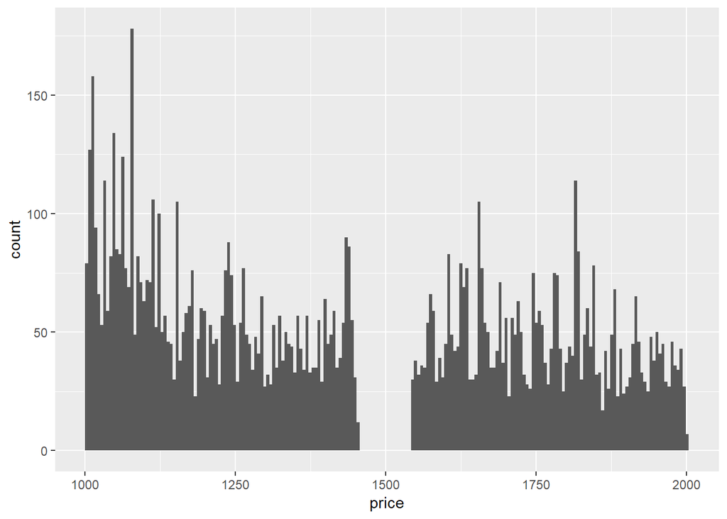

```r
ggplot(filter(diamonds, price<2000, price>1000)) + geom_histogram(aes(x = price),bins = 200)
```

price 1500근처에서 비어있다.

# 3.

```r
paste0('0.99 carat인 다이아몬드의 개수는 : ',
       diamonds %>% filter(carat == 0.99) %>% nrow())
```

```
## [1] "0.99 carat인 다이아몬드의 개수는 : 23"
```

```r
paste0('1 carat인 다이아몬드의 개수는 : ',
       diamonds %>% filter(carat == 1) %>% nrow())
```

```
## [1] "1 carat인 다이아몬드의 개수는 : 1558"
```

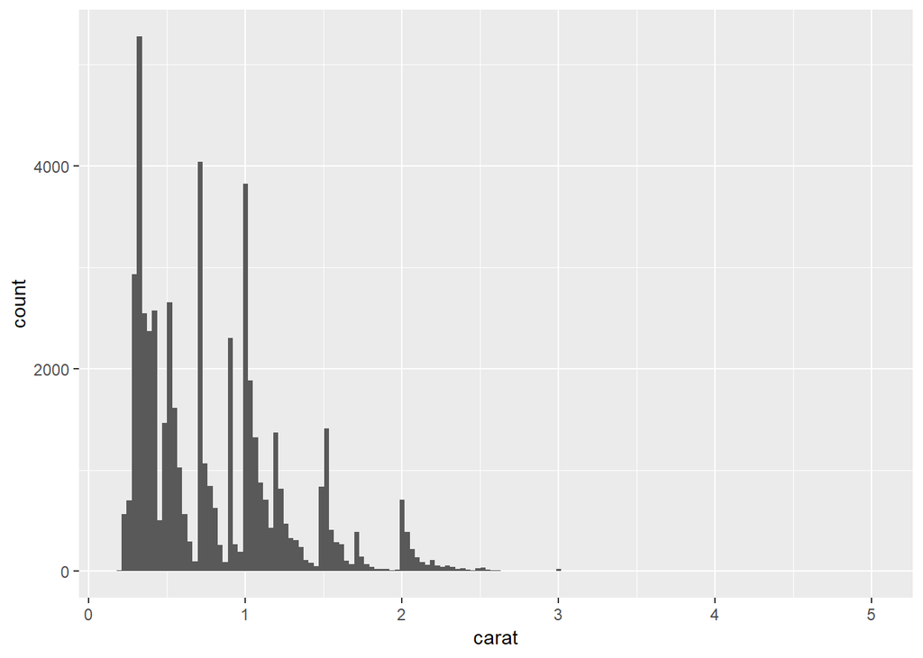

```r
ggplot(diamonds)+geom_histogram(aes(carat), bins = 150)
```

carat의 전체적인 분포를 살펴보면, 특정 값들에서 유난히 많은 개수를 갖고 있다. 0.99캐럿, 1캐럿 다이아몬드의 개수도 이 사실에 미루어 보았을 때, 특정 값으로 반올림하지 않았을까하는 추측을 해볼 수 있다.

# 4.

```r
summary(diamonds$carat)
```

```
##    Min. 1st Qu.  Median    Mean 3rd Qu.    Max.
##  0.2000  0.4000  0.7000  0.7979  1.0400  5.0100
```

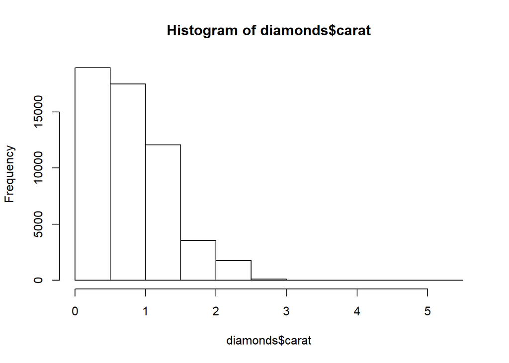

```r
hist(diamonds$carat)
```

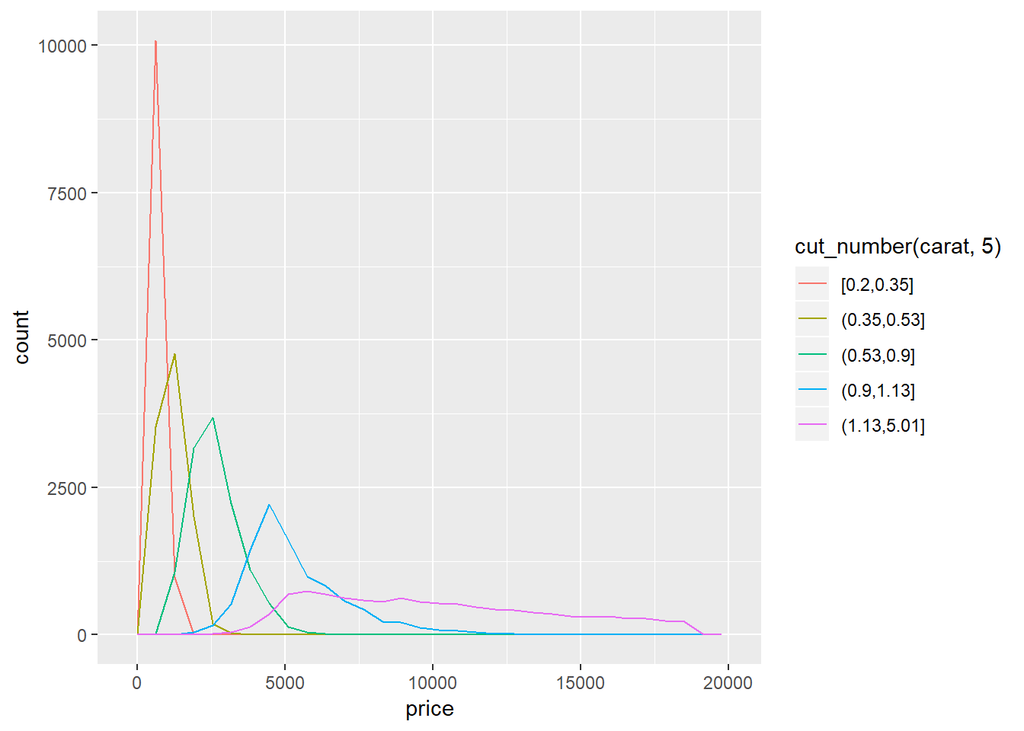

```r
#cut_number
ggplot(data = diamonds) +
  geom_freqpoly(aes(price, color = cut_number(carat,5)))
```

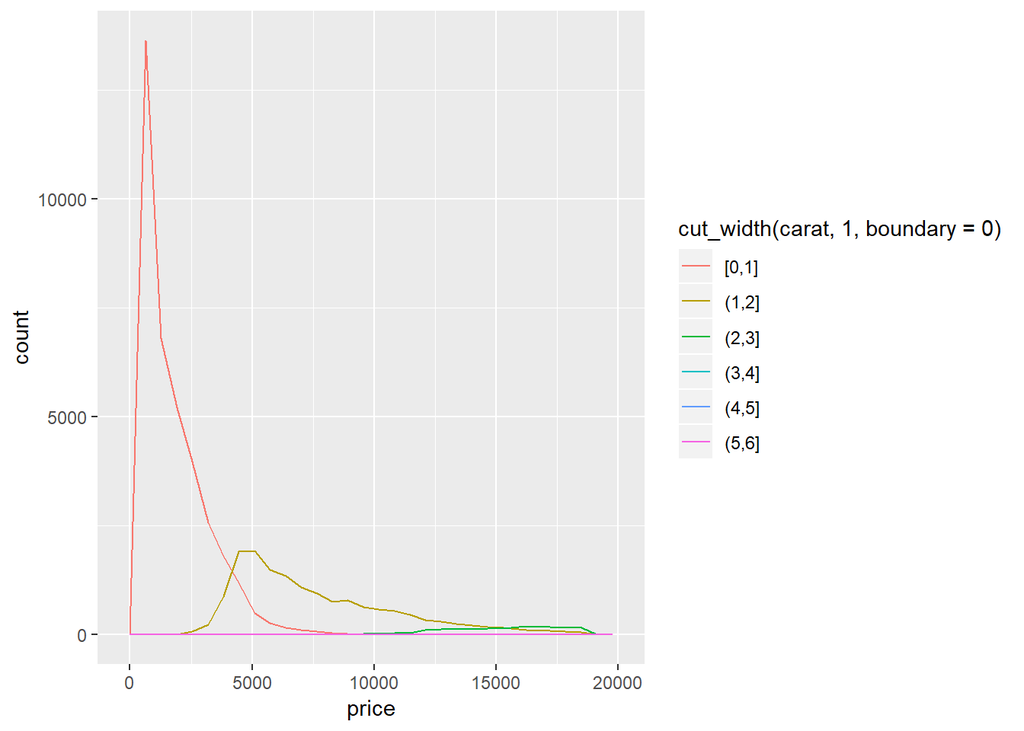

```r
#cut_width
ggplot(diamonds) +
  geom_freqpoly(aes(price,
                    color = cut_width(carat, 1, boundary = 0)))
```

cut_number는 구간의 정확한 개수를 지정해줘야하고, cut_width는 구간의 구간길이를 지정해주면 된다. cut_number는 구간의 개수를 지정해주기 때문에 구간의 길이가 등간격이 아니지만, 한 구간에 같은 개수의 자료가 들어간다. cut_width는 구간의 길이를 등간격으로 지정한다.

캐럿별 가격을 살펴보려고 할 때, cut_number가 좀 더 informative한 것 같다.

# 5.

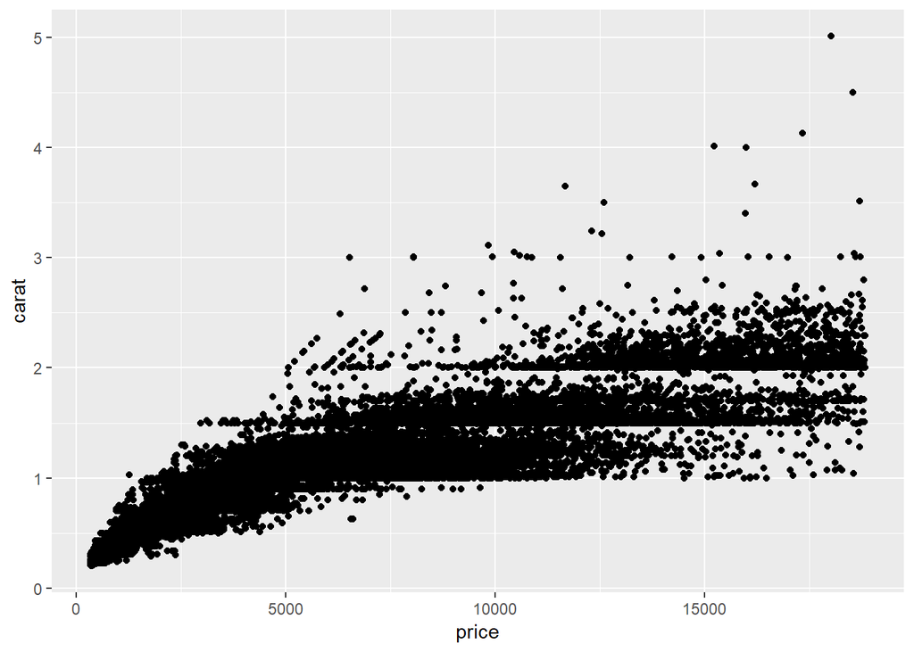

```r
ggplot(diamonds) + geom_point(aes(price, carat))
```

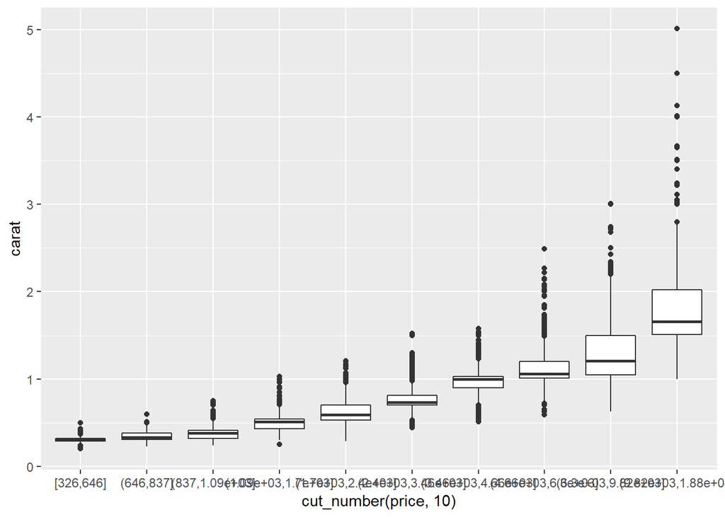

```r
ggplot(diamonds) + geom_boxplot(aes(cut_number(price, 10), carat))
```

그냥 산점도를 그렸을 때도 가격이 오를수록 carat이 커지는 것을 알 수 있었지만, 구간별 boxplot으로 나타냄으로써 더 뚜렷한 경향을 볼 수 있다.

# 6.

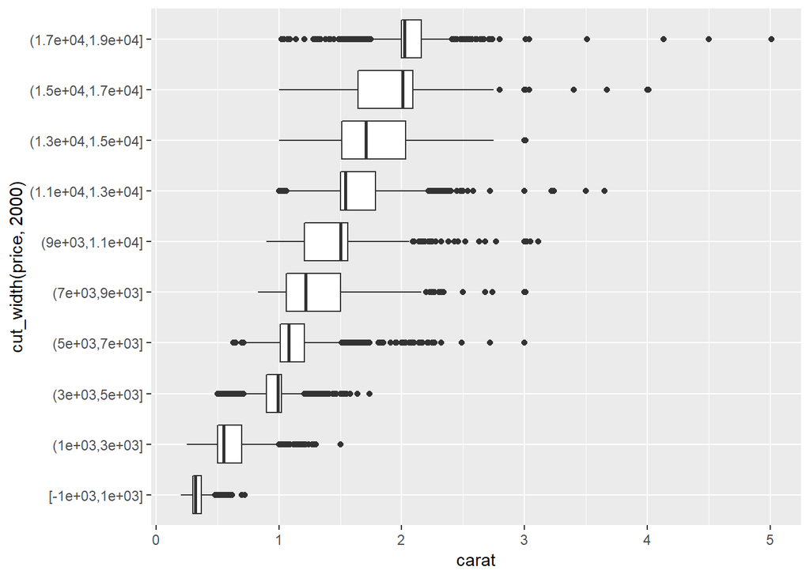

```r
ggplot(diamonds) +
  geom_boxplot(aes(cut_width(price, 2000), carat)) +
  coord_flip()
```

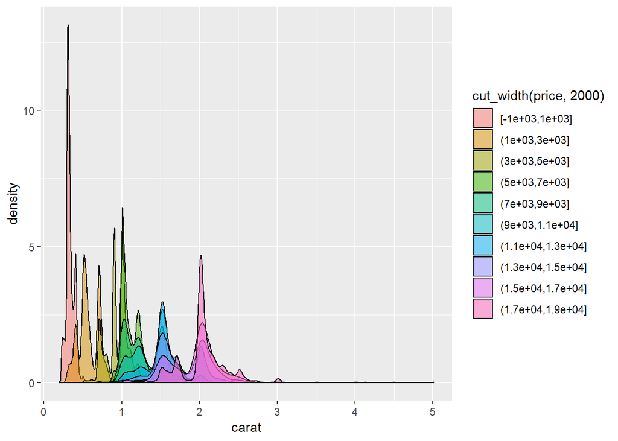

```r
ggplot(diamonds, aes(carat, fill = cut_width(price, 2000))) +
  geom_density(alpha = 0.5)
```

가격이 비싼 다이아몬드의 경우, carat의 분포가 넓은 것을 알 수 있다. 평균적으로 보면, 큰 다이아몬드일수록 캐럿이 크지만, 좀더 자세히 살펴보면, 특정 캐럿의 다이아몬드의 가격이 높게 측정된 것을 알 수 있다. 소비자들이 선호하는 특정 캐럿의 다이아몬드가 있는 것이 아닌가 유추해볼 수 있다.

# 7.

### 1)

```r
tb_cases <- table2 %>% filter(type == 'cases') %>%
  rename(cases = count) %>% select(-type)
tb_cases
```

```
## # A tibble: 6 x 3
##   country      year  cases
##   <chr>       <int>  <int>
## 1 Afghanistan  1999    745
## 2 Afghanistan  2000   2666
## 3 Brazil       1999  37737
## 4 Brazil       2000  80488
## 5 China        1999 212258
## 6 China        2000 213766
```

### 2)

```r
tb_pop <-table2 %>% filter(type == 'population') %>%
  rename(population = count) %>% select(-type)
tb_pop
```

```
## # A tibble: 6 x 3
##   country      year population
##   <chr>       <int>      <int>
## 1 Afghanistan  1999   19987071
## 2 Afghanistan  2000   20595360
## 3 Brazil       1999  172006362
## 4 Brazil       2000  174504898
## 5 China        1999 1272915272
## 6 China        2000 1280428583
```

### 3)

```r
tb_case_by_pop <- left_join(tb_cases, tb_pop) %>%
  mutate(case_by_pop = cases / population * 10000)
tb_case_by_pop
```

```
## # A tibble: 6 x 5
##   country      year  cases population case_by_pop
##   <chr>       <int>  <int>      <int>       <dbl>
## 1 Afghanistan  1999    745   19987071       0.373
## 2 Afghanistan  2000   2666   20595360       1.29
## 3 Brazil       1999  37737  172006362       2.19
## 4 Brazil       2000  80488  174504898       4.61
## 5 China        1999 212258 1272915272       1.67
## 6 China        2000 213766 1280428583       1.67
```

### 4)

```r
bind_rows(table2,
      tb_case_by_pop %>% select(-cases, -population) %>%
  mutate(type = 'case_by_pop')
  %>% rename(count = case_by_pop)) %>% arrange(country, year)
```

```
## # A tibble: 18 x 4
##    country      year type          count
##    <chr>       <int> <chr>         <dbl>
##  1 Afghanistan  1999 cases       7.45e+2
##  2 Afghanistan  1999 population  2.00e+7
##  3 Afghanistan  1999 case_by_pop 3.73e-1
##  4 Afghanistan  2000 cases       2.67e+3
##  5 Afghanistan  2000 population  2.06e+7
##  6 Afghanistan  2000 case_by_pop 1.29e+0
##  7 Brazil       1999 cases       3.77e+4
##  8 Brazil       1999 population  1.72e+8
##  9 Brazil       1999 case_by_pop 2.19e+0
## 10 Brazil       2000 cases       8.05e+4
## 11 Brazil       2000 population  1.75e+8
## 12 Brazil       2000 case_by_pop 4.61e+0
## 13 China        1999 cases       2.12e+5
## 14 China        1999 population  1.27e+9
## 15 China        1999 case_by_pop 1.67e+0
## 16 China        2000 cases       2.14e+5
## 17 China        2000 population  1.28e+9
## 18 China        2000 case_by_pop 1.67e+0
```

# 8.

```r
stocks <- tibble(
    year = rep(c(2015,2016), each = 2),
    half = c(1,2,1,2),
    return = c(1.88, 0.59, 0.92, 0.17)
)

stocks %>% spread(year, return)
```

```
## # A tibble: 2 x 3
##    half `2015` `2016`
##   <dbl>  <dbl>  <dbl>
## 1     1   1.88   0.92
## 2     2   0.59   0.17
```

```r
stocks %>% spread(year, return) %>%
  gather('year', 'return','2015':'2016')
```

```
## # A tibble: 4 x 3
##    half year  return
##   <dbl> <chr>  <dbl>
## 1     1 2015    1.88
## 2     2 2015    0.59
## 3     1 2016    0.92
## 4     2 2016    0.17
```

spread후 gather를 했을 때, year의 type은 double 이 아닌 chr로 되어 있다. spread하였을 때, year의 값들(2015,2016)이 column name으로 변환되면서, chr 타입으로 바뀌었다. 다시 gather를 통해 불러오는 과정을 통해 chr타입으로 변환되었기 때문이다.

# 9.

```r
preg <- tribble(
  ~pregnant, ~male, ~female,
  'yes', NA, 10,
  'no', 20, 12
)

preg
```

```
## # A tibble: 2 x 3
##   pregnant  male female
##   <chr>    <dbl>  <dbl>
## 1 yes         NA     10
## 2 no          20     12
```

```r
preg %>% gather('sex','count','male','female')
```

```
## # A tibble: 4 x 3
##   pregnant sex    count
##   <chr>    <chr>  <dbl>
## 1 yes      male      NA
## 2 no       male      20
## 3 yes      female    10
## 4 no       female    12
```

‘pregnant’,‘sex’,’count’를 변수로 갖는 tidy data 형태로 만들었다.